# CM3015: Machine Learning and Neural Networks

# End of term coursework submission [002]: March 2024

Step 1: Defining the Problem and assembling a dataset  
Step 2: Choosing a measure of success and metrics to monitor  
Step 3: Deciding on an evaluation protocol  
Step 4: Data Preparation  
Step 5: Developing an underfitting model with statistical power  
Step 6: Scaling - Developing a model that overfits  
Step 7: Model Regularization and hyperparameter tuning  
Retrain and testing of final model  
Results  
Evaluation  
Appendices  
- Appendix A: Code to implement SMOTETomek  
- Appendix B: Comparing the performance of a model trained on non-SMOTETomek data (before removal of class 7)  
References

Introduction to the Dataset: The dataset I have chosen for this coursework submission [002] is the ‘EMG Data for Gestures’ dataset from the UC Irvine Machine Learning Repository. The original dataset (published on UCI) was published in the form of multiple .csv files (separated by gesture and test subject) ;  
I found this dataset published on Kaggle formatted as 1 .csv file) The Data can be viewed at the following sources:  
https://archive.ics.uci.edu/dataset/481/emg+data+for+gestures  
https://www.kaggle.com/datasets/sojanprajapati/emg-signal-for-gesture-recognition?resource=download

The neural network for this project is trained on the ‘EMG data for gestures’ dataset from the UC Irvine Machine Learning Repository. The dataset collection method involved placing a ‘MYO Thalmic bracelet’ on a test subject’s forearm; this device houses 8 EMG (electromyography) sensors which monitor the level of electrical activity in response to muscle-nerve stimulation. Test subjects were asked to perform 7 gestures (1- hand at rest, 2 - hand clenched in a fist, 3 - wrist flexion, 4 - wrist extension, 5 - radial deviations, 6 - ulnar deviations, 7 - extended palm). The aim of this project is utilise the 8 EMG channels to classify the gesture performed. Gesture recognition based on the MYO Thalmic bracelet could enable gesture based interaction with nearby devices (perhaps a nearby smart tv).

# Step 1: Defining the Problem and assembling a dataset

#### Input data is in the following forms:

- EMG signals across 8 channels ; research paper 'Techniques of EMG signal analysis: detection, processing, classification and applications' defines EMG as a 'biomedical signal that measures electrical currents generated in muscles during its contraction representing neuromuscular activities.' (Mohd, 2006)
- a label (identifying a study participant),
- a timestamp.

#### Output / Target:

The model will aim to classify the gesture based on the input data; gestures are classifed into the following groups: (1- hand at rest, 2 - hand clenched in a fist, 3 - wrist flexion, 4 - wrist extension, 5 - radial deviations, 6 - ulnar deviations, 7 - extended palm)

Each data input corresponds to 1 gesture ; this defines the problem as 'single label multiclass classification'

# Step 2: Choosing a measure of success and metrics to monitor

During the initial phases of this coursework, I uncovered an imbalance in the class distribution (with respect to classes '0' and '7') - this can be seen in Step 4: Data Preparation). I researched techniques to resolve class imbalance and decided to use a combination of SMOTE (synthetic minority oversampling technique) and Tomek Links (under sampling). I selected SMOTETomek over random oversampling as random oversampling can decrease the variance of the dataset which can potentially lead to an overfitting model, whilst SMOTE [developed by Chawla et al. (2002)] 'generates a new observation that exists on a line between observations'. (Pao, 2021) The advantage of combining SMOTE with Tomek links is that it effectively 'cleans' the dataset ; ambiguous points 'Tomek Links' are removed. (Truong, 2022) Further explanation and the code used to implement SMOTETomek can be seen in Appendix A

I read recommendations to not apply SMOTETomek to the testing / validation data as it will introduce artifical data into the test set. (Nair, 2022) Once I reached the validation stage, the validation data was of a different class distribution to the training set ; this resulted in noise / fluctuations in the validation loss. The fluctations made it difficult to categorise the overall pattern of the learning curve (eg underfitting or overfitting). On realising this, I modified my approach to remove both minority classes 0 and 7 (0 is 'unlabelled data' and 7 was noted in the data documentation as only recorded for some test participants).

I utilised the 'stratify' parameter of scikit learn's train_test_split method to perform a stratified split of the data ; this ensured that the class distribution of train, valiation and test data were balanced. I felt that a stratified split was important as an imbalanced class distribution can skew the accuracy of some evaluation metrics; a random model could potentially acheive a high accuracy by predicting only the majority class (Brownlee, 2021).

I selected the metrics below for the following reasons:

- F1 Score: as the F1 score is calculated as the harmonic mean of precision and recall; maximizing the F1 score simultanesously maximizes both precision and recall (Logunova & guide, 2023)
- Cohen Kappa ; an advantage of the Cohen Kappa metric is that it compensates for classifications that may be due to chance (Arie, 2008). Cohen Kappa scores range from [-1, 1]. Negative scores indicate a disagreement between two raters; positive scores indicate agreement between. A score of 0 indicates agreement by chance. (TensorFlow, 2023)

I decided to use both (F1 score and Cohen Kappa) to evaluate performance as a model can indicate good performance on one metric, but indicate suboptimal performance on another (Buhl, 2023).

# Step 3: Deciding on an evaluation / validation protocol

Following the recommendation of the textbook 'Deep Learning with Python' (Chapter 4.5.3) (Chollet, 2018) I will use the hold out validation technique as there seems to be plenty of data available (over 1 million data samples).  
[The textbook notes that K-fold cross validation and K-fold validation are often used in the context of small volumes of data)

An article published by Machine Learning Platform 'Saturn Cloud' recommends using the 'random_state' parameter when performing an sklearn train-test split. The use of random_state ensures that experiment results are reproducible and comparable ; 'fixing' the train-test split ensures that this is not a cause of performance deterioration.(Saturn Cloud, 2023)

# Step 4: Data Preparation

```python
import pandas as pd
#https://www.kaggle.com/datasets/sojanprajapati/emg-signal-for-gesture-recognition?resource=download
#https://archive.ics.uci.edu/dataset/481/emg+data+for+gestures
data = pd.read_csv('./Data/EMG-data.csv', sep=',')
data
```

|  | time | channel1 | channel2 | channel3 | channel4 | channel5 | channel6 | channel7 | channel8 | class | label |
| --- | --- | --- | --- | --- | --- | --- | --- | --- | --- | --- | --- |
| 0 | 1 | 0.00001 | -0.00002 | -0.00001 | -0.00003 | 0.00000 | -0.00001 | 0.00000 | -0.00001 | 0 | 1 |
| 1 | 5 | 0.00001 | -0.00002 | -0.00001 | -0.00003 | 0.00000 | -0.00001 | 0.00000 | -0.00001 | 0 | 1 |
| 2 | 6 | -0.00001 | 0.00001 | 0.00002 | 0.00000 | 0.00001 | -0.00002 | -0.00001 | 0.00001 | 0 | 1 |
| 3 | 7 | -0.00001 | 0.00001 | 0.00002 | 0.00000 | 0.00001 | -0.00002 | -0.00001 | 0.00001 | 0 | 1 |
| 4 | 8 | -0.00001 | 0.00001 | 0.00002 | 0.00000 | 0.00001 | -0.00002 | -0.00001 | 0.00001 | 0 | 1 |
| ... | ... | ... | ... | ... | ... | ... | ... | ... | ... | ... | ... |
| 4237902 | 50962 | 0.00001 | -0.00001 | -0.00002 | -0.00004 | -0.00012 | 0.00000 | 0.00002 | 0.00002 | 0 | 36 |
| 4237903 | 50963 | 0.00001 | -0.00001 | -0.00002 | -0.00004 | -0.00012 | 0.00000 | 0.00002 | 0.00002 | 0 | 36 |
| 4237904 | 50964 | 0.00001 | -0.00001 | -0.00002 | -0.00004 | -0.00012 | 0.00000 | 0.00002 | 0.00002 | 0 | 36 |
| 4237905 | 50965 | 0.00001 | -0.00001 | -0.00002 | -0.00004 | -0.00012 | 0.00000 | 0.00002 | 0.00002 | 0 | 36 |
| 4237906 | 50966 | 0.00001 | -0.00001 | -0.00002 | -0.00004 | -0.00012 | 0.00000 | 0.00002 | 0.00002 | 0 | 36 |

4237907 rows × 11 columns

### Assessment of class distribution:

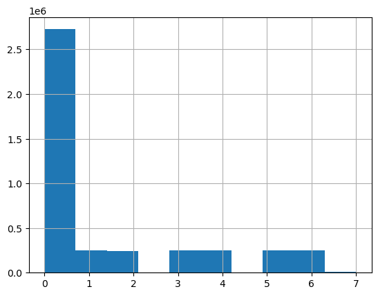

```python
data['class'].hist()
```

#### The class distribution in the histogram is unbalanced ; looking at the data documentation class '0' signifies 'unmarked data'. I will remove all data with class '0' to resolve this imbalance.

```python
df = data.drop(data[data['class'] == 0].index)
print(data.shape)
print(df.shape)
```

```
(4237907, 11)
(1512750, 11)
```

Removal of data points labelled class 0 has left 1,512,750 data samples ; a sufficient volume for training.

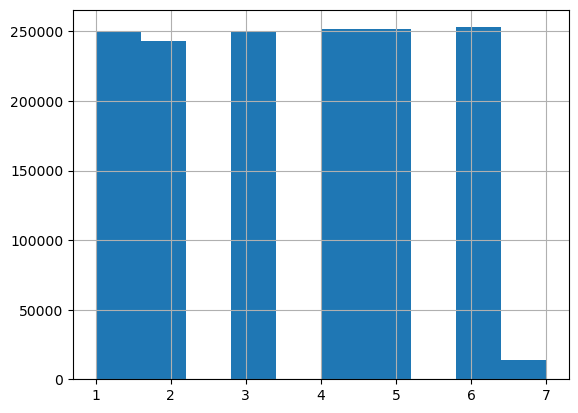

```python
df['class'].hist()
```

The distribution of classes 1-6 appear to be relatively balanced ; however class 7 has fewer samples. I shall further examine this using the pandas .value_counts() method:

```python
import math

print('Average number of class samples:')
average_class_count = math.ceil(df['class'].value_counts().mean())
print(average_class_count)
print('Number of class 7 samples:')
class_7_count = df['class'].value_counts()[7]
print(class_7_count)
print("Difference in samples size:")
print(average_class_count-class_7_count)
print("% of class samples that are class 7:")
total_class_count = df['class'].value_counts().sum()
print(class_7_count/total_class_count * 100)
```

```
Average number of class samples:
216108
Number of class 7 samples:
13696
Difference in samples size:
202412
% of class samples that are class 7:
0.9053710130556933
```

Class 7 Samples consititue less than 1% of total class samples; this suggests a severe imbalance in the data. This discrepancy is noted in the data documentation; '7 - extended palm (the gesture was not performed by all subjects).' (UC Irvine Machine Learning Repository, 2019). In the inital phases of this coursework I split the data and implemented SMOTETomek Links to resolve the class imbalance in the training data (this code can be seen in Appendix A). SMOTETomek links was not applied to the validation and test set (as it would introduce synthetic data into the model evaluation procedure) ; this resulted in noise in the learning curves that made it difficult to assess overall trend (ie underfitting or overfitting). My next approach was to remove the minority class '7' from the dataset as it did not contain samples from every test participant:

```python
mask = df['class'] == 7
df_2 = df[~mask]
y = df_2.pop('class')
x = df_2.drop(columns=['time'])
```

## Considering whether the 'label' feature should be removed:

The 'label' column identifies the subject who performed the gesture ; this feature could prove useful in making accurate, personalised gesture recognition:  
The following quote from the research paper 'Techniques of EMG signal analysis: detection, processing, classification and applications' suggests it may be useful to keep the label: EMG 'is dependent on the anatomical and physiological properties of muscles. EMG signal acquires noise while traveling through different tissues.' (Mohd, 2006) This suggests that EMG signals could have unique variations and be useful in making accurate personalised predictions.

```python
from sklearn.model_selection import train_test_split

# I originally trained the model on the entire dataset (1,499,054) however the time to train the model
#(both locally and on Google Colab V100 GPU) became too large during hyperparameter tuning
#the updated training test split, using roughly 1/8 of the data, can be seen below

# x_train, x_remaining = train_test_split(x, train_size=0.7, random_state=42)
# y_train, y_remaining = train_test_split(y, train_size=0.7, random_state=42)

# x_val, x_test = train_test_split(x_remaining, test_size=0.5, random_state=42)
# y_val, y_test = train_test_split(y_remaining, test_size=0.5, random_state=42)



#80/10/10 split ;
x_train, x_test, y_train, y_test = train_test_split(x,y, train_size=0.12, test_size=0.012, random_state=42, stratify=y)

x_train, x_val, y_train, y_val = train_test_split(x_train, y_train, test_size=0.1, random_state=42, stratify=y_train)

#confirm that split was performed correctly
# print(len(x_train))
# print(len(x_val))
# print(len(x_test))
# sum = len(x_train) + len(x_val) + len(x_test)
# print(len(x_val)/sum*100)
```

```python
#store class counts (to calculate statistical baseline) before one hot encoding transforms the data
y_train_class_count = y_train.value_counts()
y_val_class_count = y_val.value_counts()
y_test_class_count = y_test.value_counts()
```

# Data Normalisation

The following reaserch paper published on PubMed Central (National Library of Medicine) suggests that the dataset should be normalized: 'Because of the inherent EMG signal variability, clinical interpretation of surface EMG signals requires normalization of the signal for physiologic interpretation and for comparison between bilateral muscles and between the same muscle on different days and between different subjects.' (McGill, 1999)

```python
from sklearn.preprocessing import MinMaxScaler
#scaler = MinMaxScaler(feature_range=(-1, 1))
scaler = MinMaxScaler()
#scale validation data
x_val_scaled = scaler.fit_transform(x_val)
#scale testing data
x_test_scaled = scaler.fit_transform(x_test)
#scale non-SMOTETomek training data ; this will be used to compare model performance trained on SMOTETomek vs non-SMOTETomek
x_train_scaled = scaler.fit_transform(x_train)
```

## Convert data to tensor form

```python
import tensorflow as tf
#convert validation data to tensor form
x_val_scaled = tf.convert_to_tensor(x_val_scaled)
#convert testing data to tensor form
x_test_scaled = tf.convert_to_tensor(x_test_scaled)
#convert training data to tensor form
x_train_scaled = tf.convert_to_tensor(x_train_scaled)
```

## One hot encoding

The textbook 'Deep Learning with Python' Chapter 3.5.9 suggested two approaches to encoding the labels in single label, multi class classification:

- one-hot encoding, categorical_crossentropy loss function
- encoding labels as integers, sparse_categorical_crossentropy loss function

According to (Crêteur, 2022) one-hot encoding allows the model to learn more effectively ; as 'integer encoding can introduce a bias into the data by implying a natural ordering between the categories' (Crêteur, 2022). With this in mind, I chose to utilize one-hot encoding for this project.  
(One hot encoding was implemented after the train-test split to mitigate train-test contamination.)

```python
from tensorflow.keras.utils import to_categorical
num_classes = len(y.value_counts())
```

The [tensorflow documentation](https://www.tensorflow.org/api_docs/python/tf/keras/utils/to_categorical) states that to_categorical infers the number of classes as max(y) + 1  
As the classes in the current dataframe are (1,2,3,4,5,6) keras infers that there are 7 classes - to resolve this I will subtract 1 from every value in the classes column ; making class numbers (0,1,2,3,4,5) - this procedure was also applied to the validation and test set:

```python
new_train_classes = [x-1 for x in list(y_train)]
new_val_classes = [x-1 for x in list(y_val)]
new_test_classes = [x-1 for x in list(y_test)]
```

```python
#one hot encode validation data
y_val = to_categorical(new_val_classes)
y_val = tf.convert_to_tensor(y_val)

#one hot encode testing data
y_test = to_categorical(new_test_classes)
y_test = tf.convert_to_tensor(y_test)

#one hot encode non-SMOTETomek training data;
#this will be used to compare model performance trained on SMOTETomek vs non-SMOTETomek
y_train = to_categorical(new_train_classes)
y_train = tf.convert_to_tensor(y_train)
```

# Step 5: Developing an underfitting model with statistical power

## Section 5: Table of F1 Outcomes:

```python
stage_5_results.sort_values(by='val_f1_score', ascending=True)
```

|  | num_hidden_layers | num_units | optimizer | learning_rate | activation_function | batch_size | num_epochs | regularization | val_f1_score |
| --- | --- | --- | --- | --- | --- | --- | --- | --- | --- |
| 0 | 0 | 2 | rmsprop | 0.001 | relu | 128 | 5 | False | 0.157849 |
| 0 | 0 | 4 | rmsprop | 0.001 | relu | 128 | 5 | False | 0.231503 |
| 0 | 0 | 8 | rmsprop | 0.001 | relu | 128 | 5 | False | 0.269033 |
| 0 | 0 | 6 | rmsprop | 0.001 | relu | 128 | 5 | False | 0.298736 |
| 0 | 0 | 10 | rmsprop | 0.001 | relu | 128 | 5 | False | 0.334771 |
| 2 | 2 | 10 | rmsprop | 0.001 | relu | 128 | 5 | False | 0.352718 |
| 3 | 3 | 10 | rmsprop | 0.001 | relu | 128 | 5 | False | 0.378242 |
| 1 | 1 | 10 | rmsprop | 0.001 | relu | 128 | 5 | False | 0.396564 |
| 4 | 0 | 10 | rmsprop | 0.001 | relu | 128 | 10 | False | 0.432506 |
| 5 | 1 | 10 | rmsprop | 0.001 | relu | 128 | 10 | False | 0.455896 |
| 8 | 0 | 10 | rmsprop | 0.001 | relu | 128 | 15 | False | 0.464227 |
| 7 | 3 | 10 | rmsprop | 0.001 | relu | 128 | 10 | False | 0.480803 |
| 6 | 2 | 10 | rmsprop | 0.001 | relu | 128 | 10 | False | 0.483957 |
| 12 | 0 | 10 | rmsprop | 0.001 | relu | 128 | 20 | False | 0.489171 |
| 10 | 2 | 10 | rmsprop | 0.001 | relu | 128 | 15 | False | 0.527253 |
| 11 | 3 | 10 | rmsprop | 0.001 | relu | 128 | 15 | False | 0.529207 |
| 14 | 2 | 10 | rmsprop | 0.001 | relu | 128 | 20 | False | 0.536040 |
| 23 | 3 | 10 | rmsprop | 0.001 | relu | 128 | 30 | False | 0.537457 |
| 15 | 3 | 10 | rmsprop | 0.001 | relu | 128 | 20 | False | 0.542709 |
| 9 | 1 | 10 | rmsprop | 0.001 | relu | 128 | 15 | False | 0.544056 |
| 16 | 0 | 10 | rmsprop | 0.001 | relu | 128 | 25 | False | 0.547732 |
| 19 | 3 | 10 | rmsprop | 0.001 | relu | 128 | 25 | False | 0.548413 |
| 18 | 2 | 10 | rmsprop | 0.001 | relu | 128 | 25 | False | 0.560880 |
| 20 | 0 | 10 | rmsprop | 0.001 | relu | 128 | 30 | False | 0.564644 |
| 13 | 1 | 10 | rmsprop | 0.001 | relu | 128 | 20 | False | 0.571100 |
| 21 | 1 | 10 | rmsprop | 0.001 | relu | 128 | 30 | False | 0.587181 |
| 22 | 2 | 10 | rmsprop | 0.001 | relu | 128 | 30 | False | 0.588983 |
| 17 | 1 | 10 | rmsprop | 0.001 | relu | 128 | 25 | False | 0.599177 |

## Section 5 Training Log:

### Calculation of Majority Class Baseline:

```python
train_baseline = y_train_class_count[y_train_class_count.idxmax()]/ sum(y_train_class_count) *100
print(f'Training data statistical baseline: {train_baseline}')
val_baseline = y_val_class_count[y_val_class_count.idxmax()]/ sum(y_val_class_count) *100
print(f'Validation data statistical baseline: {val_baseline}')
test_baseline = y_test_class_count[y_test_class_count.idxmax()]/ sum(y_test_class_count) *100
print(f'Test data statistical baseline: {test_baseline}')
```

```
Training data statistical baseline: 16.878015034250172
Validation data statistical baseline: 16.876980376896995
Test data statistical baseline: 16.876980376896995
```

On reflection and further research I realised that the above was not directly comparabale to the F1 evaluation of the model; Further research identified that the common sense baseline is calculated on the test set (Brownlee, 2020)

With this in mind, I calculated the following common sense baseline:

[ Baseline models were trained on the preprocessed data - not the raw data - this decision was influenced by the following: 'A healthy baseline begins with clean and well-preprocessed data...Ensuring data quality lays the groundwork for meaningful baseline comparisons.' (iguazio, 2024) ]

```python
from sklearn.dummy import DummyClassifier
from sklearn.metrics import classification_report
from sklearn.metrics import precision_recall_fscore_support as score
#random baseline: calculated on validation data
dummy_clf = DummyClassifier(strategy="uniform")
#the sklearn docs define 'uniform' as follows:
#'generates predictions uniformly at random from the list of unique classes observed in y, i.e. each class has equal probability.'
#(scikit learn, 2024)
dummy_clf.fit(x_train_scaled, y_train)
y_pred_dummy = dummy_clf.predict(x_val)
precision,recall,fscore,support=score(y_val,y_pred_dummy,average='macro')
val_common_sense_baseline = fscore
val_common_sense_baseline
```

```
0.250846781011201
```

```python
#random baseline: calculated on test data
dummy_clf = DummyClassifier(strategy="uniform")
#the sklearn docs define 'uniform' as follows:
#'generates predictions uniformly at random from the list of unique classes observed in y, i.e. each class has equal probability.'
#(scikit learn, 2024)
dummy_clf.fit(x_train_scaled, y_train)
y_pred_dummy = dummy_clf.predict(x_test)
precision,recall,fscore,support=score(y_test,y_pred_dummy,average='macro')
test_common_sense_baseline = fscore
test_common_sense_baseline
```

```
0.24845913243835804
```

## This identifies:

## a validation data 'common sense baseline' (random baseline, f1 score) of 0.25

## a test data 'common sense baseline' (random baseline, f1 score) of 0.25

I defined a custom callback to pass to the 'callbacks' parameter of keras.model.fit ; this custom callback displays a plot of the training/validation loss and the training/validation evaluation metrics (F1 and Cohen Kappa):

```python
from keras.callbacks import Callback
import numpy as np
import matplotlib.pyplot as plt

class CustomCallback(Callback):

    def __init__(self):
            fig, (ax1, ax2, ax3, ax4) = plt.subplots(1,4, figsize=(15,5))
            self.ax1 = ax1
            self.ax2 = ax2
            self.ax3 = ax3
            self.ax4 = ax4

    def on_train_end(self, logs=None):
        plt.tight_layout()
        self.plotLossOverview()
        self.plotLossDetail()
        self.plotAccuracy()
        self.plotKappa()

    #the following function 'plotLoss' has been modified sourced from the textbook "Deep Learning with Python"
    #graphs are not plotted on sub axis
    def plotLossOverview(self):
        loss = self.model.history.history['loss']
        val_loss = self.model.history.history['val_loss']
        epochs = range(1, len(loss) + 1)
        self.ax1.plot(epochs, loss, 'g', label='Training loss')
        self.ax1.plot(epochs, val_loss, 'b', label='Validation loss')
        self.ax1.set_title('Training and validation loss - Overview')
        self.ax1.set_xlabel('Epochs')
        self.ax1.set_ylabel('Loss')
        #specify y axis to make the results comparable
        self.ax1.set_ylim(0,1.7)
        self.ax1.legend()

    def plotLossDetail(self):
        loss = self.model.history.history['loss']
        val_loss = self.model.history.history['val_loss']
        epochs = range(1, len(loss) + 1)
        self.ax2.plot(epochs, loss, 'g', label='Training loss')
        self.ax2.plot(epochs, val_loss, 'b', label='Validation loss - Detail')
        self.ax2.set_title('Training and validation loss')
        self.ax2.set_xlabel('Epochs')
        self.ax2.set_ylabel('Loss')
        self.ax2.legend()

        #add an identifier ready to compare results
        caption_txt = f'^ {len(self.model.layers)-2} Hidden layers, {max(epochs)} epochs, {[self.model.layers[x].units for x in range(0, len(self.model.layers)-1) if self.model.layers[x].__class__.__name__ == "Dense"]} units ^'
        self.ax2.text(0.9, -0.2, caption_txt, size=12,
                      transform=self.ax2.transAxes, horizontalalignment='right')

    #the following function 'plotAccuracy' has been modified from the textbook "Deep Learning with Python"
    def plotAccuracy(self):
        f1 = self.model.history.history['f1_score']
        val_f1 = self.model.history.history['val_f1_score']
        #each item in the history[f1_score] is an array of values - the summary during training displays this array as the mean
        f1 = [np.mean(x) for x in f1]
        val_f1 = [np.mean(x) for x in val_f1]
        loss = self.model.history.history['loss']
        epochs = range(1, len(loss) + 1)
        self.ax3.plot(epochs, f1, 'g', label='Training F1')
        self.ax3.plot(epochs, val_f1, 'b', label='Validation F1')
        self.ax3.set_title('Training and validation F1 Score')
        self.ax3.set_xlabel('Epochs')
        self.ax3.set_ylabel('F1 Score')
        self.ax3.legend()
        self.ax3.set_ylim(0,1)

    def plotKappa(self):
        kappa = self.model.history.history['cohen_kappa']
        val_kappa = self.model.history.history['val_cohen_kappa']
        loss = self.model.history.history['loss']
        epochs = range(1, len(loss) + 1)
        self.ax4.plot(epochs, kappa, 'g', label='Training Cohen Kappa')
        self.ax4.plot(epochs, val_kappa, 'b', label='Validation Cohen Kappa')
        self.ax4.set_title('Training and validation Cohen Kappa')
        self.ax4.set_xlabel('Epochs')
        self.ax4.set_ylabel('Cohen Kappa Score')
        self.ax4.legend()
        self.ax4.set_ylim(-1,1)
```

#### The custom callback above originally used matplotlib's autoscaling axis feature; however during experimentation I realised that this resulted in learning curves that were difficult to compare: (an example is provided below)

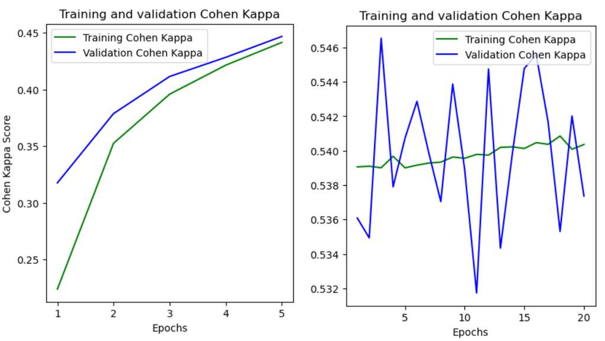

```python
from IPython.display import Image
Image(filename="./images/learning_curve_scale_issue.png", width='700')
```

#### In order to make the results (learning curves) more comparable I updated the custom callback above to specify axis size. I added an overview and a detailed plot of the training validation loss as this may help to compare losses and identify overfitting.

```python
from keras import models
from keras import layers
from keras import metrics
import tensorflow_addons as tfa
import tensorflow as tf

class NeuralNet:
    #layers should be an array of keras.layers.Dense / keras.layers.Dropout
    def __init__(self, layersArr):
        self.model = models.Sequential(layersArr)
        self.call_back_functions = [CustomCallback()]
        self.hyperparameters = {
            "optimizer": None,
            "learning_rate": None,
            "batch_size": None,
            "epochs_number": None,
            "loss_function": None,
            #weight initialisation technique

            #the following 2 are covered by layersArr ?
            #number of hidden layer
            #number of neurons in hidden layer
            #activation functions
        }
        #as the evaluation metrics are predefined to compare models - I shall assign them at initialisation
        #precision and recall are only for binary classfication?
        #tf.keras.metrics.Precision(), tf.keras.metrics.Recall(),
        self.metricsArr = [tf.keras.metrics.F1Score(), tfa.metrics.CohenKappa(num_classes=num_classes)],

    def compile_model(self):
        self.model.compile(loss=self.hyperparameters['loss_function'],
                                               optimizer=self.hyperparameters['optimizer'],
                                               metrics=self.metricsArr)

    def fit(self, x_train, y_train, validation_data, verboseParam=1, isCallback=True):
        if (isCallback):
            self.history = self.model.fit(x_train, y_train,
                                          validation_data = validation_data,
                                          epochs=self.hyperparameters['epochs_number'],
                                          batch_size=self.hyperparameters['batch_size'],
                                          callbacks=self.call_back_functions,
                                          verbose=verboseParam
                                          )
        else:
            self.history = self.model.fit(x_train, y_train,
                                          validation_data = validation_data,
                                          epochs=self.hyperparameters['epochs_number'],
                                          batch_size=self.hyperparameters['batch_size'],
                                          verbose=verboseParam
                                          )
            plt.close()

    def test(self, x_test, y_test):
        #LOOK INTO ANY MORE PARAMETERS FOR THIS
        #NEED TO RETURN THE RESULTS OR ASSIGN THEM TO A CLASS PROPERTY ?
        test_loss, test_acc, *remaining = self.model.evaluate(x_test, y_test)
        return (test_loss, test_acc, *remaining)

    #Setter functions
    def set_hyperparameters(self, new_hyperparameters_obj):
        for key, value in new_hyperparameters_obj.items():
            self.hyperparameters[key] = value


    def add_call_back_function(self, newFunc):
        self.call_back_functions.append(newFunc)
```